# CÁLCULO DIFERENCIAL E INTEGRAL

# FUNCIONES Y SUS LÍMITES

## LÍMITES QUE INVOLUCRAN INFINITOS

En esta lección, investigamos el comportamiento global de funciones y, en particular, cuando sus gráficas aproximan *asíntotas* verticales u horizontales.

### Límites infinitos

Como pudimos observar anteriormente, el límite de $$f(x)=\dfrac{1}{x^2}$$ cuando $x\to 0$ *no existe*:

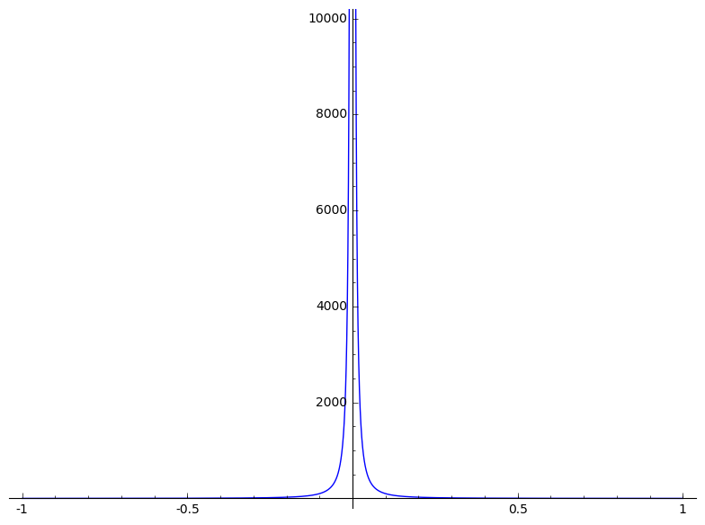

```python
f(x)=1/x^2
intervalo = (x,-1,1)
plot(f, intervalo, ymin=0, ymax=10000)
```

Sin embargo, como podemos observar, cuando aproximamos $x=0$ por ambos lados, observamos un patrón:

```python
import numpy as np

izquierda = np.linspace(-1,0,11)

for x in izquierda:
    try:
        print(x, f(x))
    except:
        print("División entre cero")
```

```
(-1.0, 1.0)
(-0.90000000000000002, 1.234567901234568)
(-0.80000000000000004, 1.5625)
(-0.69999999999999996, 2.0408163265306123)
(-0.59999999999999998, 2.777777777777778)
(-0.5, 4.0)
(-0.39999999999999991, 6.250000000000003)
(-0.29999999999999993, 11.111111111111114)
(-0.19999999999999996, 25.00000000000001)
(-0.099999999999999978, 100.00000000000004)
División entre cero
```

```python
derecha = np.linspace(1,0,11)

for x in derecha:
    try:
        print(x, f(x))
    except:
        print("División entre cero")
```

```
(1.0, 1.0)
(0.90000000000000002, 1.234567901234568)
(0.80000000000000004, 1.5625)
(0.69999999999999996, 2.0408163265306123)
(0.59999999999999998, 2.777777777777778)
(0.5, 4.0)
(0.39999999999999991, 6.250000000000003)
(0.29999999999999993, 11.111111111111114)
(0.19999999999999996, 25.00000000000001)
(0.099999999999999978, 100.00000000000004)
División entre cero
```

#### Ejercicio

Repita el ejercicio, comenzando ahora en $x=-0.1$ por la izquierda, y en $x=0.1$ por la derecha.

Ya sea por la izquierda o por la derecha, la función sigue creciendo de manera arbitraria cuando $x\to0$.

Esto motiva la siguiente definición

#### Definición

Diremos que $f(x) \to \infty$ cuando $x\to c$ si los valores de $f(x)$ pueden hacerse arbitrariamente grande si $x$ es suficientemente cercano a $c$ en este caso escribimos $$ \lim_{x\to a} f(x) = \infty $$

#### Ejercicio

¿Cuál sería el límite de $$f(x)=-\dfrac{1}{x^2}$$ cuando $x\to 0$?

#### Límites laterales

[figure not shown]

Si $f(x)\to \pm\infty$ cuando $x\to a^{\pm}$, diremos que la recta vertical $x=a$ es una **asíntota vertical**.

### Ejercicio

- Trace la gráfica de la función $$f(x) = \dfrac{2x}{x-3} $$
- Determine $$\lim_{x\to 3^+}f(x)$$
- Determine $$\lim_{x\to 3^-}f(x)$$

#### Ejercicio

Trace la gráfica de de $\tan(x)$ y determine sus asíntotas vérticales. *Sugerencia: Recuerde que $\tan(x)=\sin(x)/\cos(x)$*

### Límites al infinito

Consideremos la función $$f(x)=\dfrac{x^2-1}{x^2+1}$$

Primero, tracemos su gráfica

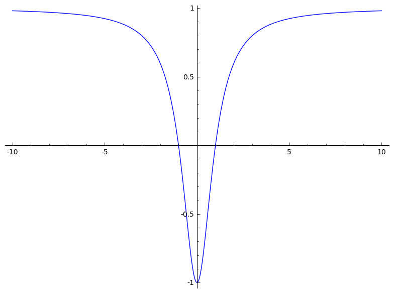

```python
f(x) = (x^2-1)/(x^2+1)
intervalo=(x,-10,10)
grafica = plot(f, intervalo)
show(grafica)
```

La gráfica nos sugiere que la función tiene un "tope" superior, al que se acerca cuando nos alejamos hacias los extremos.

Verifiquemos este comportamiento:

```python
for x in np.linspace(0,100,11):
    print(x,f(x))
```

```
(0.0, -1)
(10.0, 0.9801980198019802)
(20.0, 0.9950124688279302)
(30.0, 0.9977802441731409)
(40.0, 0.9987507807620237)
(50.0, 0.9992003198720512)
(60.0, 0.9994445987225771)
(70.0, 0.9995919200163232)
(80.0, 0.9996875488204967)
(90.0, 0.9997531168991483)
(100.0, 0.9998000199980003)
```

```python
for x in np.linspace(0,-100,11):
    print(x,f(x))
```

```
(0.0, -1)
(-10.0, 0.9801980198019802)
(-20.0, 0.9950124688279302)
(-30.0, 0.9977802441731409)
(-40.0, 0.9987507807620237)
(-50.0, 0.9992003198720512)
(-60.0, 0.9994445987225771)
(-70.0, 0.9995919200163232)
(-80.0, 0.9996875488204967)
(-90.0, 0.9997531168991483)
(-100.0, 0.9998000199980003)
```

En efecto, los cálculos númericos nos sugieren que cuando $x\to \pm \infty$, es decir, $x$ tiende a los extremos, $f(x) \to 1$.

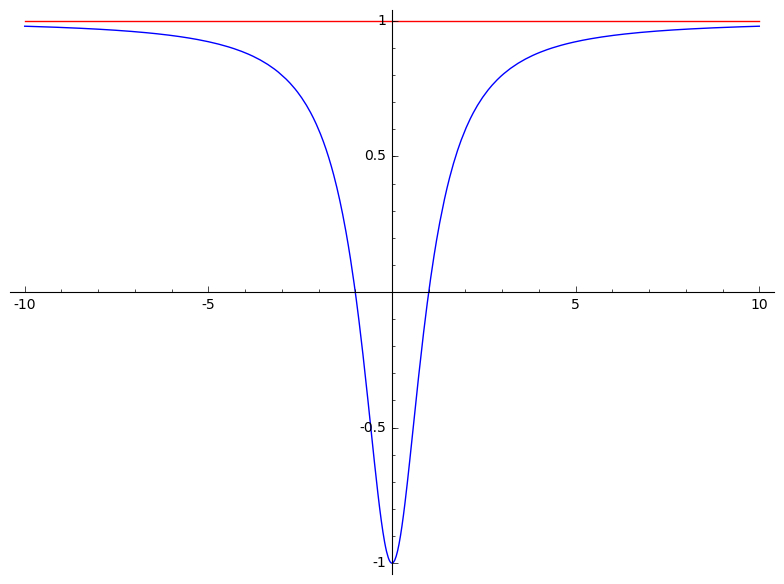

```python
g(x)=1
asintota = plot(g, intervalo, color="red")
show(grafica+asintota)
```

#### Definición

Sea $f$ una función definida en algún intervalo $(a,\infty)$. Entonces $$ \lim_{\infty} f(x) = L $$ significa que los valores de $f(x)$ se pueden hacer arbitrariamente cercanos a $L$ si $x$ es suficientemente grande.

Hagamos un experimento numérico para ilustar la definición. Vamos a encontrar $x$ tal que $$ |1-f(x)|< \epsilon $$ donde $\epsilon$ es un margen de error dado.

```python
error = 0.001
x = 0

while(np.abs(1-f(x))>=error):
    x+=1

print(x, f(x).n())
```

```
(45, 0.999012833168806)
```

Grafiquemos la función a partir de este número

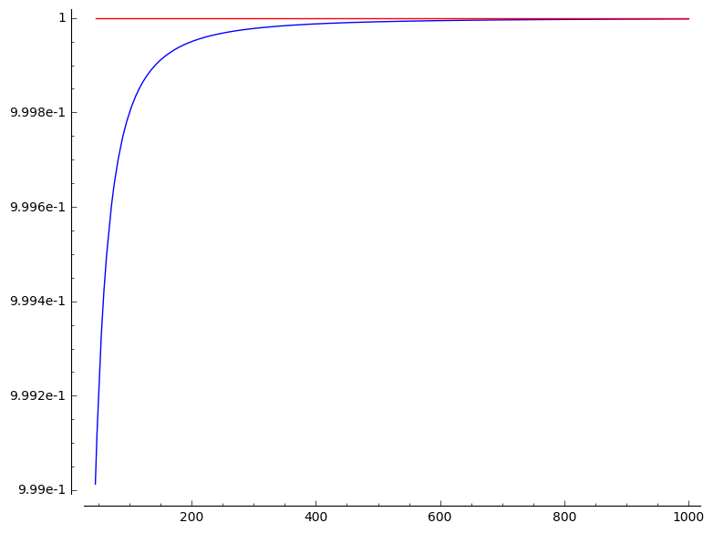

```python
infinito = 10^3
al_infinito = (x,45,infinito)
grafica_2 = plot(f, al_infinito)
asintota_2 = plot(g, al_infinito, color="red")
show(grafica_2+asintota_2)
```

##### Ejercicio

Determine gráfica y númericamente el comportamiento asíntotico ($x\to \pm \infty$) de las siguientes funciones:

1. $f(x)=\frac{1}{x} $
2. $g(x)=\frac{1}{x^2} $
3. $h(x)=\frac{1}{x^3} $

¿Qué comportamiento observa para las funciones de la forma $\frac{1}{x^n}$ con $n$ entero positivo?

##### Ejercicio

Determine gráfica y númericamente el comportamiento asíntotico ($x\to \pm \infty$) de las siguientes funciones:

1. $$ f(x) = \dfrac{3x^2-x-2}{5x^+4x+1} $$
2. $$ g(x) = \sqrt{x^2+1}-x$$
3. $$ h(x) = \sin\left(\dfrac{1}{x}\right) $$

### Límites infinitos en el infinito

##### Ejercicio

Determine gráfica y númericamente el comportamiento asíntotico ($x\to \pm \infty$) de las siguientes funciones:

1. $f(x)=x^3$
2. $g(x)=x^2-x$
3. $h(x)=\dfrac{x^2+x}{3-x}$

#### Definición

Sea $f$ una función definida en algún intervalo $(a,\infty)$. Entonces

$$\lim_{x\to \infty} f(x) = \infty $$

significa que para cada número positivo $M$ existe un correspondiente número positivo $N$ tal que si $x>N$, entonces $f(x) > M$

### Ejemplo

Sea $f(x)= x^3$ y elijamos $M=10,000$. Determinaremos cual es la $N$ correspondiente:

```python
f(x) = x^3
x = 0
M = 10000
while(f(x)<=M):
    x+=1
print(x, f(x))
```

```
(22, 10648)
```

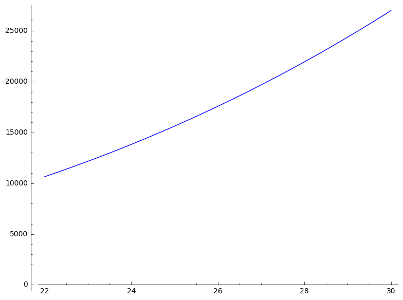

```python
infinito = 30
intervalo = (x, 22, infinito)
plot(f, intervalo, ymin=0)
```